# RNA-seq data cleaning

Uganda HIV+ : TB-induced RSTR vs LTBI

Basilin Benson basilinb@uw.edu

version January 23, 2023

# Background

The purpose of this workflow is to complete basic data cleaning of metadata and RNA-seq libraries. This includes 1) removing low coverage libraries, 2) filtering rare genes, 3) removing outlying libraries and duplicates, and 4) normalizing for RNA composition.

# Setup

Load packages

```r
# Empirical analysis of digital gene expression data
## Data normalization
library(edgeR)
library(limma)

# Data manipulation and figures
library(tidyverse)
library(openxlsx)
  # Modify ggplot figures to non-overlapping text labels
  library(ggrepel)
  # Modify ggplot data order within facets
  library(drlib)
  # Plot log scales
  library(scales)
  #Multi-panel figures
  library(patchwork)
  #Custom plots
  library(BIGpicture)

# reference genome
library(biomaRt)

# Print pretty table to knit file
library(knitr)
library(kableExtra)
  options(knitr.kable.NA = '')
  opts_chunk$set(fig.pos = 'H')

#Create 'not in' operator
`%notin%` <- Negate(`%in%`)
select <- dplyr::select
rename <- dplyr::rename
filter <- dplyr::filter
distinct <- dplyr::distinct
mutate <- dplyr::mutate
```

Create Directory Structure

```r
dir.create("results",showWarnings = FALSE,recursive = FALSE)
dir.create("fig",showWarnings = FALSE,recursive = FALSE)
```

Set seed

```r
set.seed(4389)
```

# Read in and format data

## Metadata

```r
meta <- read_csv("data_raw/2021.03.10RSTR_Hawn_metadata.csv") %>%
  filter(HIVSTAT_CURRENT == "Y")
```

Add CD4 count data

```r
cd4 <- read.xlsx("data_raw/RSTR_LTBI metadata_HIV_pos 062111.xlsx") %>%
  separate(libID, into = c("RS_SUB_ACCESSION_NO"),
           extra = "drop") %>%
  mutate(CD4 = as.numeric(CD4_RESULT1)) %>%
  distinct(RS_SUB_ACCESSION_NO, CD4) %>%
  #add cutoff groups
  mutate(CD4_color = case_when(CD4 <= 200 ~"<200",
                               CD4 <= 1000 ~ "between 200 and 1000",
                               CD4 > 1000 ~ ">1000"))


meta <- meta %>%
  left_join(cd4)
```

## Counts: HIV+

```r
count_hiv_pos <- read_tsv("data_raw/rstr-hiv-pos.featurecounts.paired.tsv", skip=1) %>%
  #Remove gene info
  select(-c(Chr:Length)) %>%
  #Clean names
  rename(ensembl_gene_id = Geneid) %>%
  rename_all(~gsub("^/home/ec2-user/project/rstr_results/bam_filter/|_filter.bam$", "", .)) %>%
  rename_all(~gsub("-", "_", .)) %>%
  rename_all(~gsub("Media", "MEDIA", .)) %>%
  #drop 0 rows
  filter_if(is.numeric, any_vars(.>0))
count.all <- count_hiv_pos %>%
  #replace NA with 0
  replace(is.na(.), 0) %>%
  #arrange cols
  select(ensembl_gene_id, sort(colnames(count_hiv_pos)))
```

## Metadata

Combine metrics with donor metadata

```r
meta.all <-  read_csv("data_raw/rstr.HIVpos.cleaning.metrics.csv") %>%
  #Add condition variable
  mutate(libID=gsub("-", "_", toupper(libID)),
         name=gsub("^[0-9]{1,2}_", "", libID)) %>%
  separate(name, into=c("RSID","condition"), sep="_") %>%
  #Add donor metadata
  left_join(meta,
            by=c("RSID"="RS_SUB_ACCESSION_NO")) %>%
  #Remove failed lib
  filter(libID %in% colnames(count.all)) %>%
  arrange(libID) %>% mutate(batch = "HIV pos")
```

Check order

```r
identical(colnames(count.all)[-1], meta.all$libID)
```

```
## [1] TRUE
```

# Data cleaning

Set cutoffs

```r
#Provide file basename
#This will be appended to the start of all file names saved to the disk
basename <- "RSTR.HIV"

#List main variables of interest
#Will be used to visualize data in tables and plots
#If > 2 variables provided, plots are not colored by variables
vars_of_interest <- c("condition","Sample_Group","HIVSTAT_CURRENT")

# Define cutoffs
#Median CV coverage MAXIMUM
CV.cut <- 1
#Alignment percentage with duplicates MINIMUM
align.cut <- 0.95
#Total sequences MINIMUM
count.cut <- 1E6
```

## Filter protein coding genes

Filter gene key to protein coding (pc) genes that occur in the count data set.

```r
#Get database
ensembl <- biomaRt::useEnsembl(biomart="ensembl", dataset="hsapiens_gene_ensembl",
                                mirror = "uswest")

#Format gene key
key <- biomaRt::getBM(attributes=c("ensembl_gene_id", "entrezgene_id", "hgnc_symbol",
                                        "gene_biotype", "chromosome_name",
                                        "start_position", "end_position"), mart=ensembl) %>%
  #Filter protein coding genes
  filter(gene_biotype == "protein_coding")

key.filter <- key %>%
  #Filter protein coding genes in count table
  filter(ensembl_gene_id %in% count.all$ensembl_gene_id) %>%
  #collapse multiannotations.
  group_by(ensembl_gene_id, hgnc_symbol, gene_biotype,
           chromosome_name, start_position, end_position) %>%
  summarise(entrezgene_id = list(unique(entrezgene_id)), .groups = "drop") %>%
  group_by(ensembl_gene_id, entrezgene_id, gene_biotype,
           chromosome_name, start_position, end_position) %>%
  summarise(symbol = list(unique(hgnc_symbol)), .groups = "drop") %>%
  arrange(ensembl_gene_id)
```

Filter the count data to pc genes as well.

This removes 27415 genes.

#### Check genes

All genes in count and key in the same order?

```
## [1] TRUE
```

## Assess library coverage

#### Median CV coverage vs. mapped duplicate reads

Compare the median coefficient of variation (CV) coverage (`median_cv_coverage`) and percent alignment of reads with duplicates (`mapped_reads_w_dups`). Ideally, you want libraries with LOW median CV coverage and HIGH percent aligned duplicates, indicating low variability in coverage over the length of genes and high coverage across the genome, respectively.

Plot CV coverage vs alignment. Samples outside the cutoff assigned above are labeled with sampID.

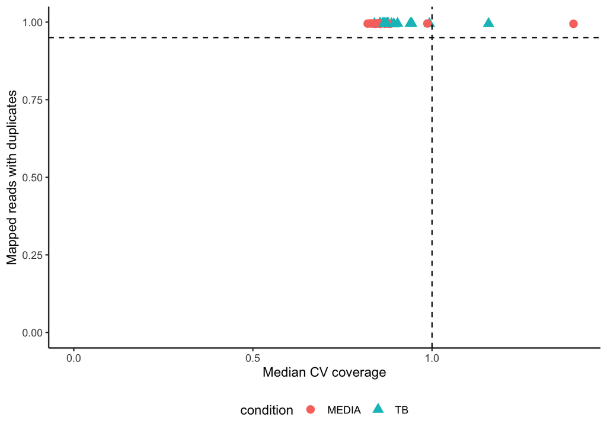

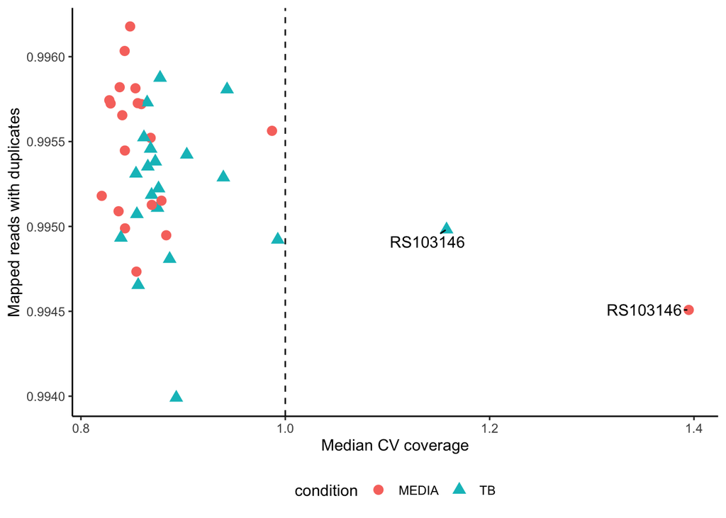

Total libraries

| Sample_Group | condition | n |
| --- | --- | --- |
| LTBI | MEDIA | 10 |
| LTBI | TB | 10 |
| RSTR | MEDIA | 10 |
| RSTR | TB | 10 |

#### Total aligned counts

Assess aligned counts per library. Higher counts indicate high coverage and are preferred.

Plot total counts per library. Libraries outside cutoffs are labeled as “questionable”. The minimum total sequences cutoff set above is indicated by a horizontal line.

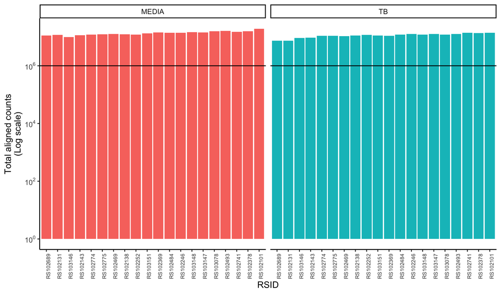

## Filter by library coverage

All libraries have sufficient sequences for analysis. Some libraries have questionable CV coverage and these will be further assessed in PCA.

## Assess PCA outliers

Visualize PCA outliers defined as any library with PC1 and/or PC2 values greater than 3 standard deviations away from the PC mean of their respective condition group.

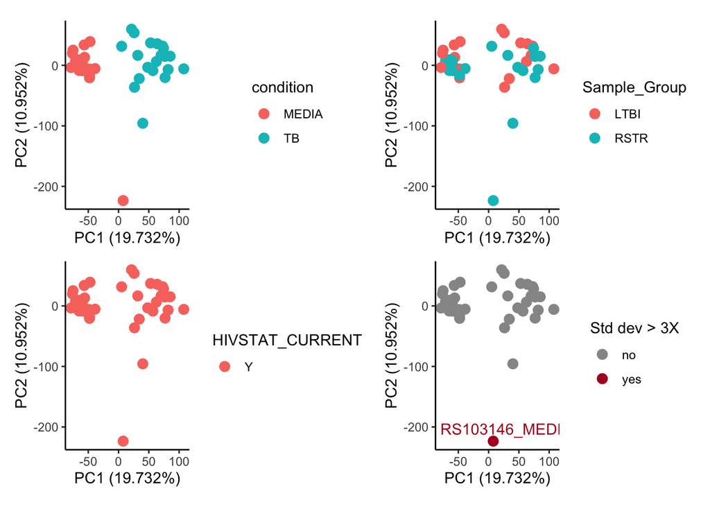

While only 1 outlier exists, the next most outlying sample is from the same donor. Given this and the paired samples design, this entire donor will be removed.

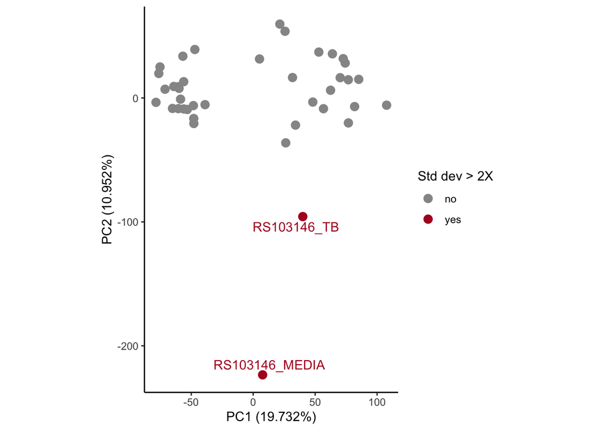

```r
plot_pca(count.all.pc,
         meta = meta.all,
         vars = "outlier",
         scale = TRUE,
         transform_logCPM = TRUE,
         outlier_sd = 2)
```

## Filter PCA outliers

Both outlier are from the same donor. Thus, remove this donor.

```r
meta.filter <- meta.all %>% filter(RSID != "RS103146")

count.filter <- count.all.pc %>%
  select(ensembl_gene_id, all_of(meta.filter$libID))
```

## Filter rare genes

Create DGEList object.

Mean Variance plot

```r
dat.abund <- RNAetc::filter_rare(dat = dat,
                                 min.CPM = 0.8,
                                 min.sample = 2,
                                 gene.var = "ensembl_gene_id")
```

```
## 3785 (20.31%) of 18634 genes removed.
```

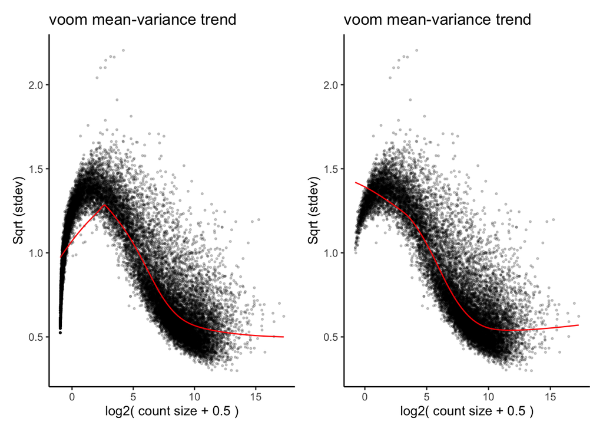

```r
MV.plot2<-BIGpicture::plot_mv(dat.abund,design = ~ condition)

MV.plot1 + MV.plot2
```

## Normalize for RNA composition

Calculate factors to scale library sizes.

```r
dat.abund.norm <- calcNormFactors(dat.abund)
```

## Normalize with voom

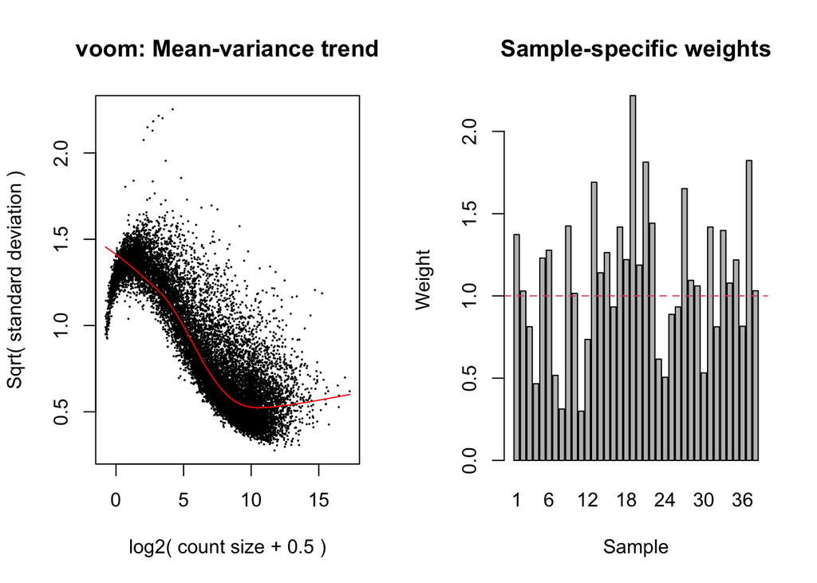

```r
dat.abund.norm.voom <- voomWithQualityWeights(
                           dat.abund.norm,
                           design=model.matrix(~ condition,
                                 data=dat.abund.norm$samples),
                           plot=TRUE)
```

## Final data

### Summarize samples

Final table of samples by group and condition

Total libraries

| Sample_Group | condition | n |
| --- | --- | --- |
| LTBI | MEDIA | 10 |
| LTBI | TB | 10 |
| RSTR | MEDIA | 9 |
| RSTR | TB | 9 |

### PCA

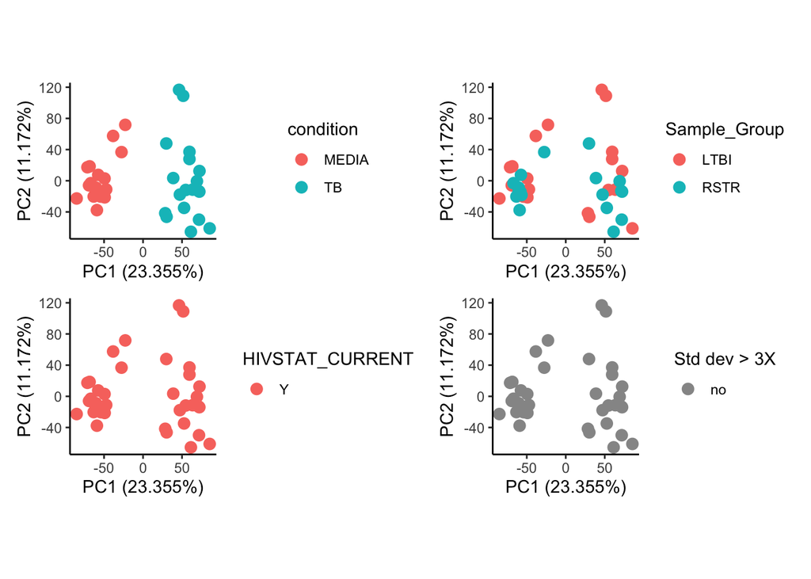

### Save final data

Write as RData

```r
#Rename to short form
dat <- dat.abund.norm
dat.voom <- dat.abund.norm.voom

save(dat,
     file="data_clean/HIV_pos_counts.RData")
save(dat.voom,
     file="data_clean/HIV_pos_voom.RData")
```